# Atividade 4 - Checkpoint 1

Dandara Sousa

22 de julho de 2017

## O conjunto de dados

Temos, aqui, uma amostra dos commits dados no [GitHub](http://github.com/) no período 2016-2017. É possível observar a quantidade de pessoas que editaram arquivos de uma determinada extensão durante os dois anos.Os dados brutos contém a contagem de quantas pessoas editaram arquivos com cada extensão de arquivo em cada dia de 2016 e 2017 no github. Não temos dados de todos os repositórios nem de todos os usuários, portanto estamos trabalhando com uma amostra.

```r
commits = read.csv("github-users-committing-filetypes.csv")

dados <- commits %>%
  unite("data", the_year, the_month, month_day, sep = "-") %>%
  mutate(data = as.Date(strptime(data, "%Y-%m-%d"))) %>%
  mutate(iswknd = is.weekend(data)) %>%
  mutate(dia_semana = weekdays(data))


names(commits)[names(commits) == "file_extension"] <- "Extensao"
names(commits)[names(commits) == "month_day"] <- "Dia"
names(commits)[names(commits) == "the_month"] <- "Mes"
names(commits)[names(commits) == "the_year"] <- "Ano"
names(commits)[names(commits) == "users"] <- "Usuarios"

unique(commits$Extensao)
```

```
##  [1] md      js      json    html    py      java    css     xml
##  [9] txt     yml     h       php     png     cpp     sh      rb
## [17] c       scss    cs      jpg     lock    go      ts      svg
## [25] gradle  csproj  rst     m       map     ttf     yaml    pbxproj
## [33] less    woff    eot     swift   cc      sql     gif     ico
## [41] config  pdf
## 42 Levels: c cc config cpp cs csproj css eot gif go gradle h html ... yml
```

As linguagens da nossa amostra são as seguintes e dentre elas vamos escolher as duas mais populares:

```r
conjunto = commits %>%
  group_by(Extensao) %>%
  summarise(nUsuarios = max(Usuarios))

linguagens = conjunto %>%
  ggplot(aes(x = reorder(Extensao, nUsuarios), y = nUsuarios)) +
  geom_bar(stat = "identity") +
  theme(axis.text.x = element_text(angle = 45, hjust = 1))+
  theme_minimal()

ggplotly(linguagens, width = 720,height = 480)
```

[interactive chart not shown]

Observando que md e js são as extensões mais populares da nossa amostra as utilizaremos para fins de análise, ou seja, vamos considerar que Markdown e Javascript são as linguagens mais populares. Por Markdown, vamos inferir que são as pessoas que programam em R. Primeiro vamos preparar os dados para nossa análise facilitando a relação de data e dia da semana.

```r
commits = commits %>% filter(Extensao == "js" | Extensao == "md")
head(commits)
```

```
##   Extensao Dia Mes  Ano Usuarios
## 1       md  18   2 2016    10279
## 2       md  17   2 2016    10208
## 3       md  27   1 2016    10118
## 4       md  16   2 2016    10045
## 5       md  26   1 2016    10020
## 6       md  21   3 2017    10015
```

```r
names(commits)
```

```
## [1] "Extensao" "Dia"      "Mes"      "Ano"      "Usuarios"
```

```r
md = commits %>% filter(Extensao == "md")

md.2016 = md %>% filter(Ano == "2016")
md.2016 = md.2016 %>%
  group_by(Mes) %>%
  mutate(Usuarios_Mes = sum(Usuarios))

md.2017 = md %>% filter(Ano == "2017")
md.2017 = md.2017 %>%
  group_by(Mes) %>%
  mutate(Usuarios_Mes = sum(Usuarios))

md = rbind(md.2016,md.2017)

js = commits %>% filter(Extensao == "js")

js.2016 = js %>% filter(Ano == "2016")
js.2016 = js.2016 %>%
  group_by(Mes) %>%
  mutate(Usuarios_Mes = sum(Usuarios))

js.2017 = js %>% filter(Ano == "2017")
js.2017 = js.2017 %>%
  group_by(Mes) %>%
  mutate(Usuarios_Mes = sum(Usuarios))

js = rbind(js.2016,js.2017)

commits = rbind(md,js)
```

## Linha do tempo

Para facilitar o entendimento da nossa amostra, vamos visualizar como as linguagens se comportam durante o tempo. É possível perceber a discrepância de valores entre extensões md e js, como ambas foram mais populares em 2016, ou seja, de como no decorrer do tempo a contagem de commits vem caindo.

```r
md1 = md %>%
  ggplot(aes(x= Mes, y = Usuarios_Mes, colour = as.factor(Ano))) +
  geom_line() +
  geom_point() +
  scale_x_continuous(breaks=c(1,3,6,9,12)) +
  labs(title = "Edições Mensalmente (Markdown)", x = "Mês" , y= "Usuários Editores", colour = "Ano") +
  theme_minimal()

ggplotly(md1, width = 720,height = 480)
```

[interactive chart not shown]

```r
js1 = js %>%
  ggplot(aes(x= Mes, y = Usuarios_Mes, colour = as.factor(Ano))) +
  geom_line() +
  geom_point() +
  scale_x_continuous(breaks=c(1,3,6,9,12)) +
  labs(title = "Edições Mensalmente (Javascript)", x = "Mês" , y= "Usuários Editores", colour = "Ano") +
  theme_minimal()

ggplotly(js1, width = 720,height = 480)
```

[interactive chart not shown]

## Popularidade por dia de semana

Para essa sessão vamos nos basear em dois questionamentos:

**1. Para cada uma das linguagens de programação, há uma diferença significativa na sua popularidade durante a semana e durante o fim de semana? Essa diferença é grande?**

Para responder essa pergunta primeiros vamos ver a produtividade dos usuários da amostra em dias de semana e finais de semana.

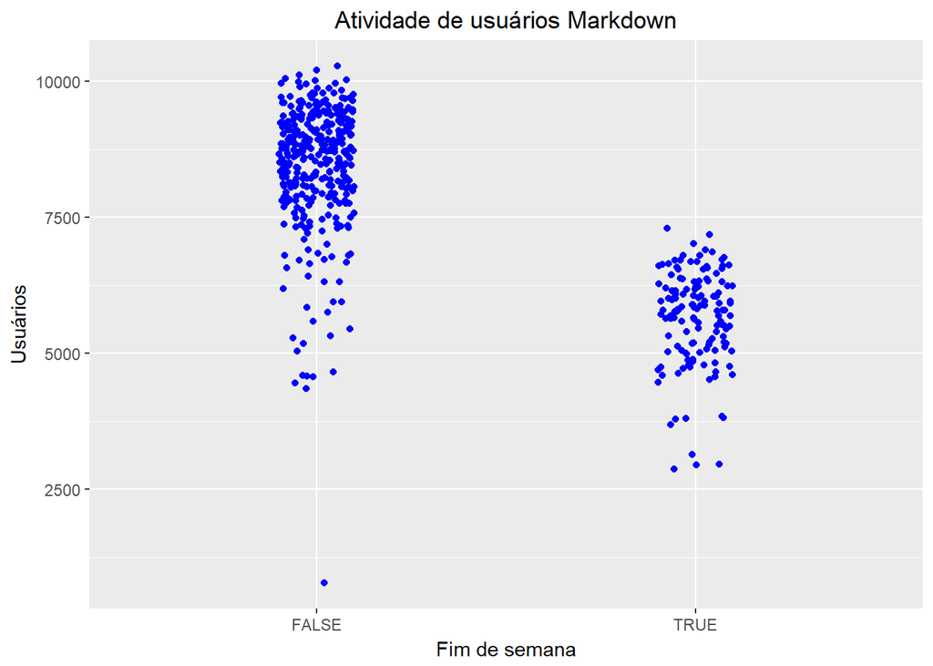

```r
md = dados %>% filter(file_extension == "md")

md_plot = md %>%
  ggplot(aes(x = iswknd, y = users)) +
  geom_jitter(width = .1, color = "blue") +
  labs(title = "Atividade de usuários Markdown", x = "Fim de semana", y = "Usuários") +
  theme(plot.title = element_text(hjust = 0.5))

md_plot
```

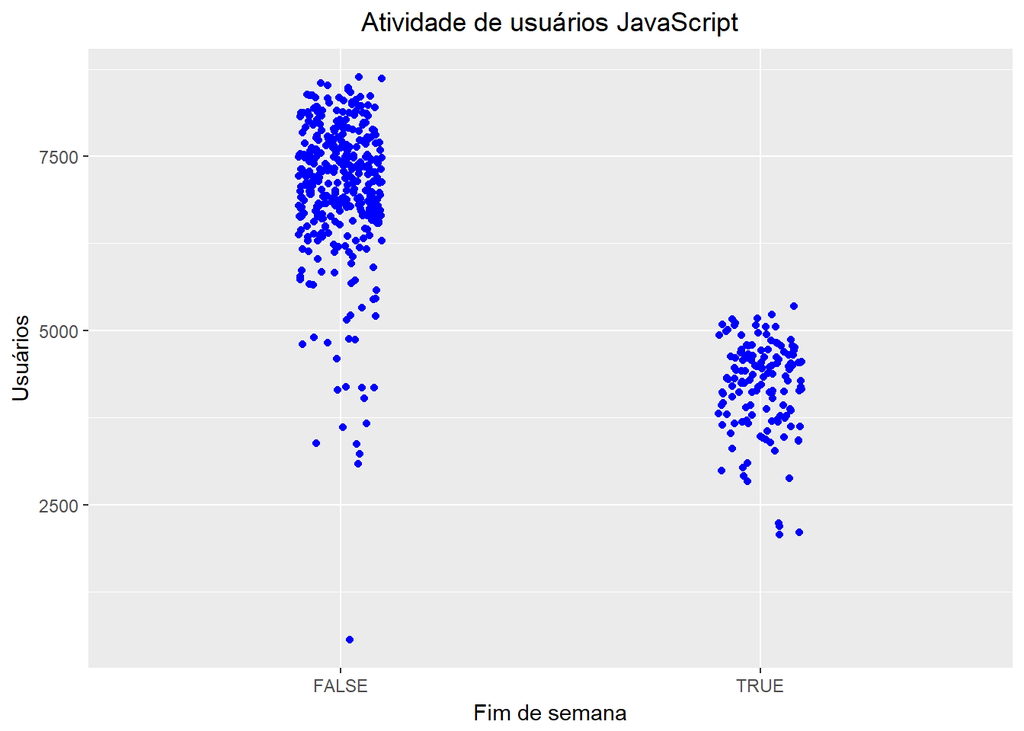

```r
js = dados %>% filter(file_extension == "js")

js_plot = js %>%
  ggplot(aes(x = iswknd, y = users)) +
  geom_jitter(width = .1, color = "blue") +
  labs(title = "Atividade de usuários JavaScript", x = "Fim de semana", y = "Usuários") +
  theme(plot.title = element_text(hjust = 0.5))

js_plot
```

A partir disso é possível notar que a distribuição de programação no final de semana é visivelmente menor que em dias úteis.

**Bootstrap**

Uma vez que estamos trabalhando com amostras, a confiabilidade é reduzida. Utilizaremos, então, o bootstrap para aumentar esta confiabilidade nos nossos resultados.

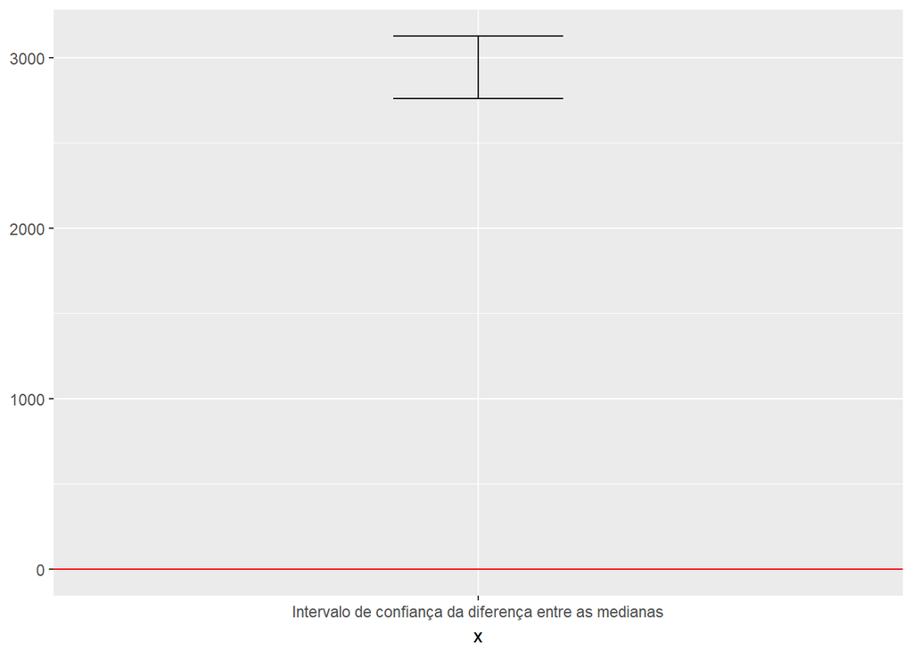

```r
mediana_md <- bootstrap2(md$users,
                         treatment = md$iswknd,
                         median,
                         R = 10000)

mediana_md_ci <- CI.percentile(mediana_md, probs = c(.025, .975))

data.frame(mediana_md_ci) %>%
  ggplot(aes(x = "Intervalo de confiança da diferença entre as medianas", ymin = X2.5., ymax = X97.5.)) +
  geom_errorbar(width = .2) +
  geom_hline(yintercept = 0, colour = "red")
```

No caso do MarkDown conseguimos notar que, com 95% de confiança, a diferença das medianas entre a atividade no fim de semana e nos dias úteis implica que existe mais codificação durante a semana do que no sábado e no domingo.

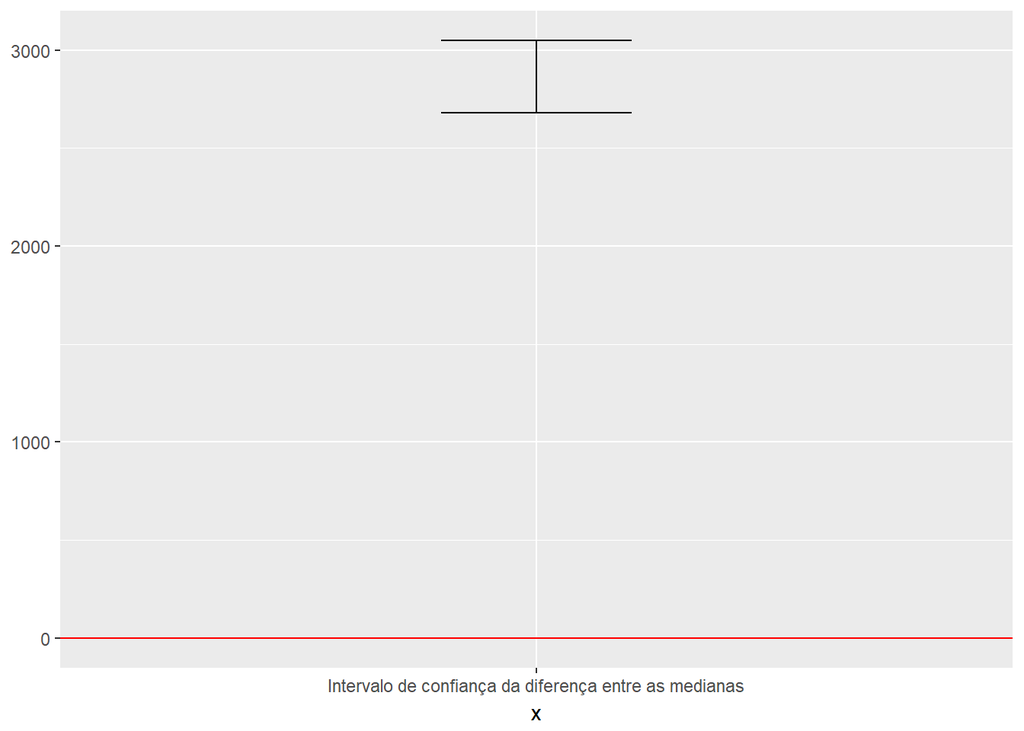

```r
mediana_js <- bootstrap2(js$users,
                         treatment = js$iswknd,
                         median,
                         R = 15000)

mediana_js_ci <- CI.percentile(mediana_js, probs = c(.025, .975))

data.frame(mediana_js_ci) %>%
  ggplot() +
  geom_errorbar(aes(x = "Intervalo de confiança da diferença entre as medianas", ymin = X2.5., ymax = X97.5.), width = .2) +
  geom_hline(yintercept = 0, colour = "red")
```

**2. Existe uma diferença significativa entre as duas linguagens na sua variação de popularidade nos finais de semana?**

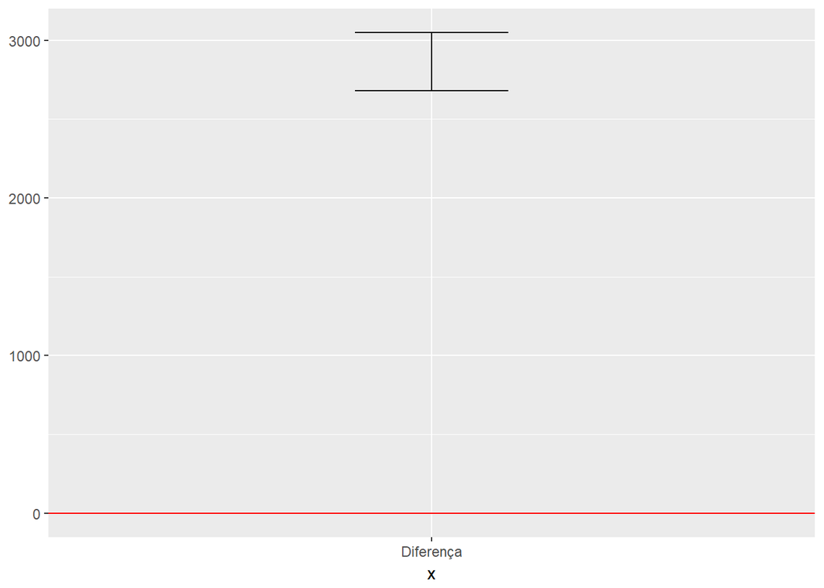

```r
sd_dif <- bootstrap2(data = (js %>% filter(iswknd == TRUE))$users,
                      data2 = (md %>% filter(iswknd == TRUE))$users,
                      sd,
                      R = 10000)
sd_dif_ci <- CI.percentile(mediana_js, probs = c(.025, .975))


data.frame(sd_dif_ci) %>%
  ggplot(aes(x = "Diferença", ymin = X2.5., ymax = X97.5.)) +
  geom_errorbar(width = .2) +
  geom_hline(yintercept = 0, colour = "red")
```